# Exercício Computacional 8

Importando libraries:

```r
library(tidyverse)
library(quantmod)
library(xts)
library(moments)
```

Setando o diretório corrente:

```r
setwd(dirname(rstudioapi::getActiveDocumentContext()$path))
getwd()
```

```
[1] "/Users/adrianosastre/Dropbox/Data Science/Exercícios/datascience-exercises-20200418-conceitos-ml/Exercícios-Computacionais/8"
```

Conceito explorado: Introdução à Análise de Séries Temporais

Esse exercício tem o objetivo de explorar o assunto de séries temporais de forma introdutória. Para isso, existem alguns pacotes que podem nos auxiliar no objetivo desse exercício: capturar séries temporais do mercado financeiro e realizar sua visualização. Abaixo, estão listados três pacotes relacionados ao mercado financeiro que podem ser instalados e carregados na linguagem R. install.packages(“quantmod”) install.packages(“xts”) install.packages(“moments”)

Esses pacotes foram desenvolvidos exclusivamente para modelagem financeira quantitativa na linguagem R e permitem capturar séries temporais sobre as cotações de ações do mercado financeiro.

Especificamente, estude e utilize a função getSymbols do pacote “quantmod” para obter séries temporais de diversas empresas presentes na bolsa de valores a partir de uma janela de tempo fornecida. Essa função consegue obter os dados diretamente das fontes “Yahoo Finance” (ainda ativo) e “Google Finance”, que disponibilizam os dados gratuitamente. Utilize o nome “yahoo” para designar a fonte de dados na função getSymbols.

1. Use a função getSymbols do pacote quantmod para capturar as cotações de ações da empresa Petrobras de janeiro/2020 até os dias atuais.
2. Use a função candleChart do pacote quantmod para fazer a visualização da série temporal das cotações fechadas da Petrobras no período considerado. Pesquise e explore essa função; esse resultado é chamado de gráfico de velas (amplamente conhecido e usado em análises do mercado financeiro).
3. Explore a série temporal obtida da empresa, teste outros períodos de tempo e identifique o significado dos campos trazidos da série.
4. Use a função addBands, também do pacote quantmod, para plotar diretamente limites superior/inferior sobre a série temporal do item 1). Podemos parametrizar a função fornecendo:
1. o período da média móvel e ii) a quantidade de desvio padrão relacionados com os limites.
5. A partir os itens anteriores, faça uma análise dos preços de cotações da Petrobras e verifique os reflexos do momento atual que estamos passando (março/abril/2020).

```r
# ==================================================================
# Seleção de Janela de Tempo das Séries Temporais

# Seleção de uma janela de tempo ou período de análise
# ?as.Date
Data_Inicio = as.Date("2020-01-01")
Data_Fim    = as.Date("2020-5-30")

# ==================================================================
# Importação de Dados

# ?getSymbols -> do pacote quantmod
# Load (carrega) e manage (gerencia) dados de múltipla fontes

# Tanto o Yahoo como o Google oferecem um serviço gratuito de monitoramento
# de ações do mercado financeiro. O serviço fornece as cotações de ações nas
# principais bolsas de valores

# Uso da função gesymbols para acessar o serviço Yahoo Finance e capturar os valores
# de ações das empresas (precisamos saber o código da empresa na bolsa)
getSymbols("PETR4.SA", src = "yahoo", from = Data_Inicio, to = Data_Fim)
```

```
PETR4.SA contains missing values. Some functions will not work if objects contain missing values in the middle of the series. Consider using na.omit(), na.approx(), na.fill(), etc to remove or replace them.
```

```
[1] "PETR4.SA"
```

```r
?getSymbols
# Verificando o tipo de objeto
class(PETR4.SA)
```

```
[1] "xts" "zoo"
```

```r
is.xts(PETR4.SA)
```

```
[1] TRUE
```

```r
# É importante verificarmos, também, a estabilidade do serviço tanto do Yahoo como do Google
# Outro ponto é a possibilidade de valores NA serem trazidos na série de temporal capturada
Serie_Temporal_Petrobras = na.omit(PETR4.SA)
Serie_Temporal_Petrobras
```

```
           PETR4.SA.Open PETR4.SA.High PETR4.SA.Low PETR4.SA.Close PETR4.SA.Volume
2020-01-02         30.51         30.70        30.31          30.70        37774500
2020-01-03         30.88         31.24        30.45          30.45        71595600
2020-01-06         30.43         30.94        29.95          30.81        81844000
2020-01-07         30.82         30.88        30.47          30.69        32822000
2020-01-08         30.69         30.77        30.24          30.50        48215600
2020-01-09         30.47         30.62        30.25          30.40        36102700
2020-01-10         30.39         30.44        30.13          30.27        25397500
2020-01-13         30.35         30.43        30.21          30.33        30676800
2020-01-14         30.23         30.27        29.77          30.00        39796500
2020-01-15         29.90         29.93        29.54          29.55        34405700
2020-01-16         29.60         29.70        29.33          29.52        28997400
2020-01-17         29.72         29.85        29.54          29.85        34908000
2020-01-20         29.70         30.10        29.65          30.00        31241400
2020-01-21         29.80         29.94        29.55          29.62        28577400
2020-01-22         29.73         29.81        29.27          29.29        32491500
2020-01-23         29.09         29.76        28.82          29.65        53752100
2020-01-24         29.56         29.78        29.14          29.30        36898700
2020-01-27         28.63         28.64        27.67          28.03        66105300
2020-01-28         28.43         29.14        28.42          28.80        47259100
2020-01-29         29.00         29.08        28.67          28.85        42297500
2020-01-30         28.28         29.04        28.18          28.94        44266800
2020-01-31         28.63         28.84        28.31          28.45        55446700
2020-02-03         28.52         28.73        28.16          28.18        39452800
2020-02-04         28.65         29.04        28.56          28.63        57658400
2020-02-05         29.05         29.22        28.39          28.39        67994500
2020-02-06         28.70         29.51        28.12          29.18       126114000
2020-02-07         29.00         29.35        28.73          28.93        54514600
2020-02-10         28.89         29.13        28.64          29.13        45328100
2020-02-11         29.40         29.63        29.26          29.48        37518200
2020-02-12         29.64         30.28        29.63          30.13        64851000
2020-02-13         29.77         30.21        29.64          29.72        55277100
2020-02-14         29.86         29.96        29.34          29.42        30399900
2020-02-17         29.63         29.77        29.31          29.36        38684900
2020-02-18         29.06         29.77        28.95          29.75        33890900
2020-02-19         29.87         30.55        29.76          30.55        44181800
2020-02-20         30.80         30.89        29.75          29.92        73522900
2020-02-21         29.51         29.68        29.03          29.14        47805100
2020-02-27         25.72         26.53        24.89          25.30       100112100
2020-02-28         25.16         25.56        24.62          25.34        89095300
```

[output cut: 111 more lines]

```
2020-04-09          16.81909
2020-04-13          16.92909
2020-04-14          16.72910
2020-04-15          16.37911
2020-04-16          15.71915
2020-04-17          16.12913
2020-04-20          15.94914
2020-04-22          16.74909
2020-04-23          16.94954
2020-04-24          15.94956
2020-04-27          16.44955
2020-04-28          17.25000
2020-04-29          18.20000
2020-04-30          18.05000
2020-05-04          17.38000
```

```r
class(Serie_Temporal_Petrobras)
```

```
[1] "xts" "zoo"
```

```r
head(Serie_Temporal_Petrobras)
```

```
           PETR4.SA.Open PETR4.SA.High PETR4.SA.Low PETR4.SA.Close PETR4.SA.Volume
2020-01-02         30.51         30.70        30.31          30.70        37774500
2020-01-03         30.88         31.24        30.45          30.45        71595600
2020-01-06         30.43         30.94        29.95          30.81        81844000
2020-01-07         30.82         30.88        30.47          30.69        32822000
2020-01-08         30.69         30.77        30.24          30.50        48215600
2020-01-09         30.47         30.62        30.25          30.40        36102700
           PETR4.SA.Adjusted
2020-01-02          30.69834
2020-01-03          30.44835
2020-01-06          30.80833
2020-01-07          30.68834
2020-01-08          30.49835
2020-01-09          30.39835
```

```r
View(Serie_Temporal_Petrobras)

# Repare que o índice desse conjunto de dados consiste em datas - caracterização da série temporal
# Observando o dataset - nós temos a cotação de abertura (open), a mais alta (high), mais baixa (low)
# a cotação de fechamento (close), finalizando com volume e cotação ajustada.

# ==================================================================
# Processando Dados da Série Temporal

# Focando nos dados de fechamento da série de tempo da petrobras
Serie_Petrobras_Close <- Serie_Temporal_Petrobras$PETR4.SA.Close
Serie_Petrobras_Close
```

```
           PETR4.SA.Close
2020-01-02          30.70
2020-01-03          30.45
2020-01-06          30.81
2020-01-07          30.69
2020-01-08          30.50
2020-01-09          30.40
2020-01-10          30.27
2020-01-13          30.33
2020-01-14          30.00
2020-01-15          29.55
2020-01-16          29.52
2020-01-17          29.85
2020-01-20          30.00
2020-01-21          29.62
2020-01-22          29.29
2020-01-23          29.65
2020-01-24          29.30
2020-01-27          28.03
2020-01-28          28.80
2020-01-29          28.85
2020-01-30          28.94
2020-01-31          28.45
2020-02-03          28.18
2020-02-04          28.63
2020-02-05          28.39
2020-02-06          29.18
2020-02-07          28.93
2020-02-10          29.13
2020-02-11          29.48
2020-02-12          30.13
2020-02-13          29.72
2020-02-14          29.42
2020-02-17          29.36
2020-02-18          29.75
2020-02-19          30.55
2020-02-20          29.92
2020-02-21          29.14
2020-02-27          25.30
2020-02-28          25.34
```

[output cut: 28 more lines]

```
2020-04-09          16.82
2020-04-13          16.93
2020-04-14          16.73
2020-04-15          16.38
2020-04-16          15.72
2020-04-17          16.13
2020-04-20          15.95
2020-04-22          16.75
2020-04-23          16.95
2020-04-24          15.95
2020-04-27          16.45
2020-04-28          17.25
2020-04-29          18.20
2020-04-30          18.05
2020-05-04          17.38
```

```r
# Verificar se temos uma série temporal
is.xts(Serie_Petrobras_Close)
```

```
[1] TRUE
```

```r
# Alternativa (notação de slide)
head(PETR4.SA)
```

```
           PETR4.SA.Open PETR4.SA.High PETR4.SA.Low PETR4.SA.Close PETR4.SA.Volume
2020-01-02         30.51         30.70        30.31          30.70        37774500
2020-01-03         30.88         31.24        30.45          30.45        71595600
2020-01-06         30.43         30.94        29.95          30.81        81844000
2020-01-07         30.82         30.88        30.47          30.69        32822000
2020-01-08         30.69         30.77        30.24          30.50        48215600
2020-01-09         30.47         30.62        30.25          30.40        36102700
           PETR4.SA.Adjusted
2020-01-02          30.69834
2020-01-03          30.44835
2020-01-06          30.80833
2020-01-07          30.68834
2020-01-08          30.49835
2020-01-09          30.39835
```

```r
dados_close <- Serie_Temporal_Petrobras[,"PETR4.SA.Close"]
dados_close
```

```
           PETR4.SA.Close
2020-01-02          30.70
2020-01-03          30.45
2020-01-06          30.81
2020-01-07          30.69
2020-01-08          30.50
2020-01-09          30.40
2020-01-10          30.27
2020-01-13          30.33
2020-01-14          30.00
2020-01-15          29.55
2020-01-16          29.52
2020-01-17          29.85
2020-01-20          30.00
2020-01-21          29.62
2020-01-22          29.29
2020-01-23          29.65
2020-01-24          29.30
2020-01-27          28.03
2020-01-28          28.80
2020-01-29          28.85
2020-01-30          28.94
2020-01-31          28.45
2020-02-03          28.18
2020-02-04          28.63
2020-02-05          28.39
2020-02-06          29.18
2020-02-07          28.93
2020-02-10          29.13
2020-02-11          29.48
2020-02-12          30.13
2020-02-13          29.72
2020-02-14          29.42
2020-02-17          29.36
2020-02-18          29.75
2020-02-19          30.55
2020-02-20          29.92
2020-02-21          29.14
2020-02-27          25.30
2020-02-28          25.34
```

[output cut: 28 more lines]

```
2020-04-09          16.82
2020-04-13          16.93
2020-04-14          16.73
2020-04-15          16.38
2020-04-16          15.72
2020-04-17          16.13
2020-04-20          15.95
2020-04-22          16.75
2020-04-23          16.95
2020-04-24          15.95
2020-04-27          16.45
2020-04-28          17.25
2020-04-29          18.20
2020-04-30          18.05
2020-05-04          17.38
```

```r
# Repare que o índice de tempo vem junto com a captura dos dados

# Alternativa (método com instrução Cl)
?Cl
# Extraçõ e transformação de colunas em time-series
Open_Series   = Op(Serie_Temporal_Petrobras)
Closed_Series = Cl(Serie_Temporal_Petrobras)

Open_Series[1]
```

```
           PETR4.SA.Open
2020-01-02         30.51
```

```r
Closed_Series[1]
```

```
           PETR4.SA.Close
2020-01-02           30.7
```

```r
?OpCl

Open_Closed_Series = OpCl(Serie_Temporal_Petrobras)
Open_Closed_Series[1]
```

```
           OpCl.Serie_Temporal_Petrobras
2020-01-02                   0.006227499
```

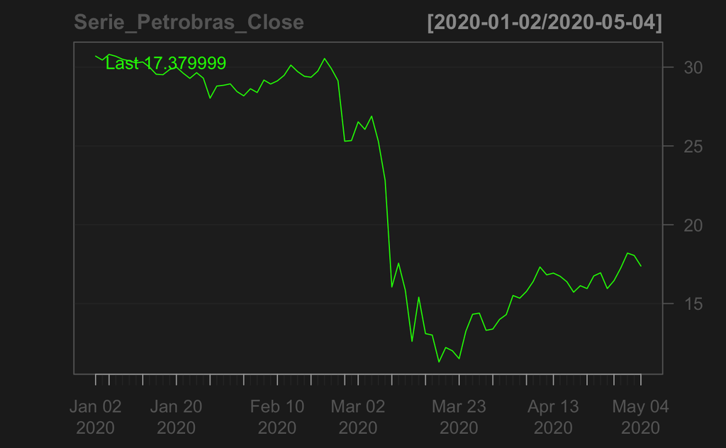

```r
# Closed_Series[1]/Open_Series[1] - 1



# ==================================================================
# Criação de Plots para Visualização da Série Temporal

# Vamos usar a função candlestick (gráfico de velas)
?candleChart
# Essa função cria charts ou gráficos padrões de visualização de séries temporais do mercado financeiro
# Procure por gráfico de velas ou candlestick - importantes para interpretação dos resultados da bolsa de valores
# Candle apenas do fechamento
candleChart(Serie_Petrobras_Close)
```

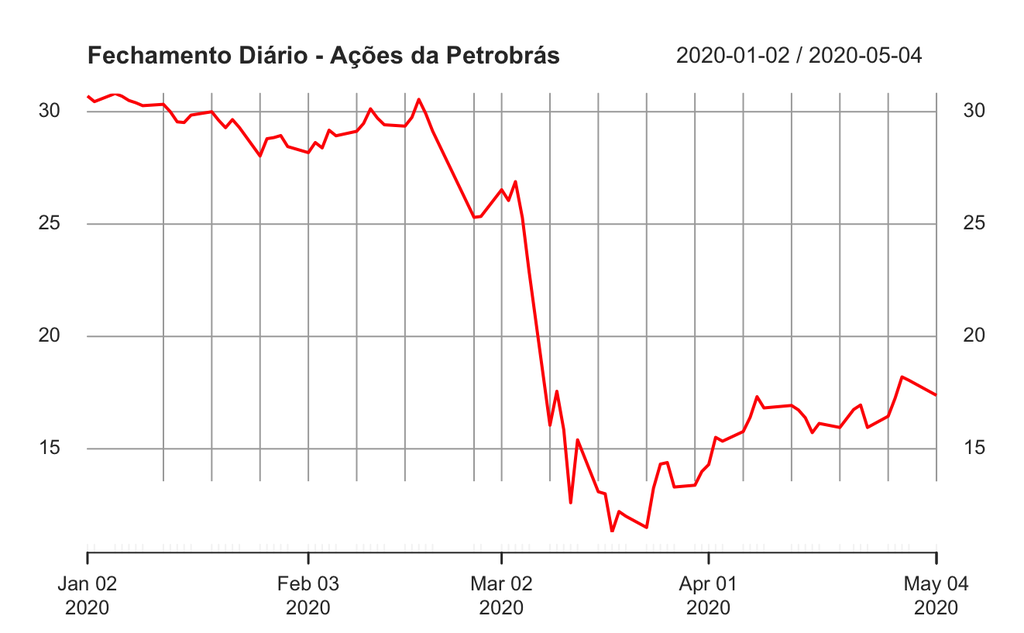

```r
# Usando a função plot para gerar as visualizações
plot(Serie_Petrobras_Close, main = "Fechamento Diário - Ações da Petrobrás",
     col = "red", xlab = "Tempo", ylab = "Preço da Ação", major.ticks = "months")
```

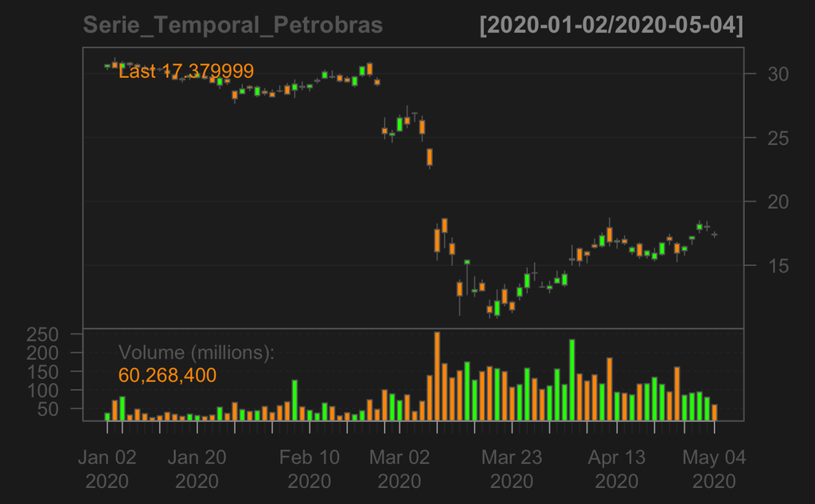

```r
# Candle com toda a série
candleChart(Serie_Temporal_Petrobras)
```